# The Resilience Paradox: Mapping EU-China Strategic Trade and Financial Fragmentation

2020–2026

Author

Alex HAAS, Viliam POHANCENIK, Pieter PEVERELLI

Published

January 26, 2026

## Introduction: The Geoeconomics of De-risking

### From Interdependence to Economic Resilience

The evolution of EU-China economic relations has undergone a fundamental departure from the *Wandel durch Handel* (change through trade) paradigm toward a strategy of “de-risking”. This shift is primarily aimed at correcting a trade deficit that reached €304.5 billion by 2024 and mitigating the risks of “coercive leverage” in critical supply chains.

Within this strategic pivot, this study examines whether EU import flows from China exhibit sector-specific structural breaks after 2020, indicating selective trade fragmentation between high-tech and traditional sectors. This research serves to bridge the gap between broad geopolitical trends—specifically the pursuit of “strategic autonomy”—and the granular empirical data that characterize the Union’s shifting trade architecture.

### Addressing Asymmetric Dependencies

Despite this clear political shift toward strategic autonomy, there remains a gap in the empirical literature regarding whether these policy objectives have successfully translated into a measurable divergence in trade flows. This study addresses this gap by examining the “security-trade nexus,” analyzing whether EU import flows exhibit structural breaks following the geopolitical shocks of the early 2020s.

We hypothesize a dual-track geoeconomic reality: while traditional, low-value-added sectors governed by market-driven cost efficiencies should remain stable, high-tech industries—subject to the EU Chips Act, foreign investment screenings, and export controls—are expected to show significant fragmentation. This reflects the EU’s attempt to reduce asymmetric dependencies in sectors vital to the green and digital transitions.

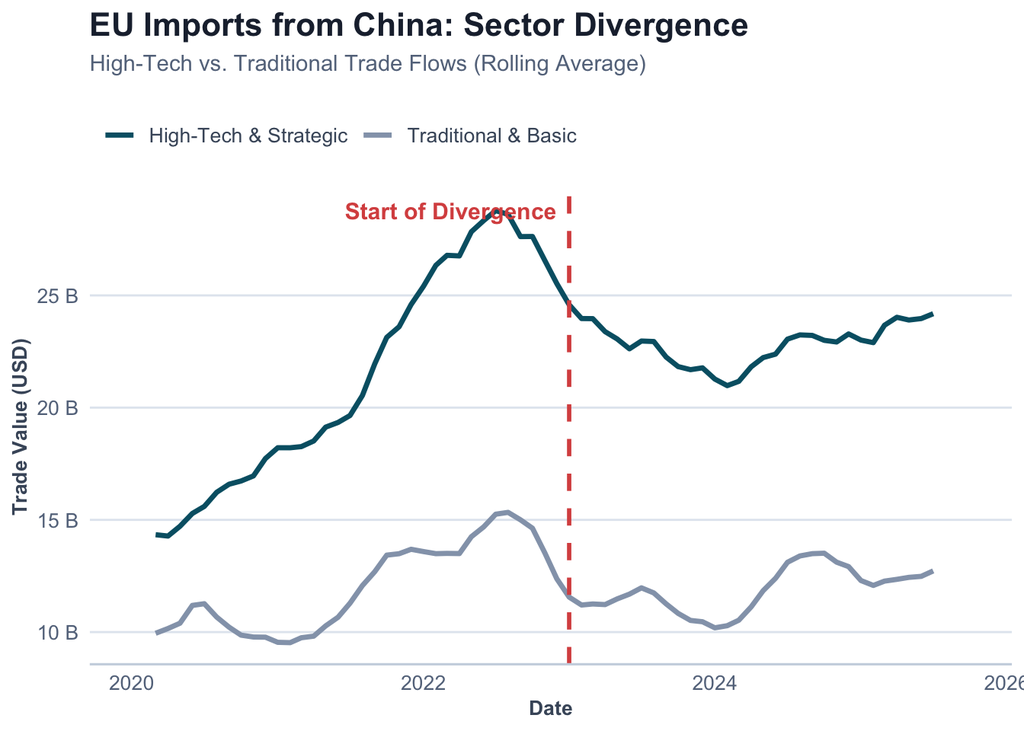

Figure 1: 3-Month Rolling Average of EU Trade with China by Sector Group. The red dashed line marks the start of the Economic Security Strategy.

## Methodology: Measuring Geoeconomic Re-securitization

### Data Acquisition and Strategic Categorization

The empirical foundation of this research rests on a high-frequency longitudinal dataset (2018–2025) constructed through automated API retrieval from the Eurostat (COMEXT) and Bank for International Settlements (BIS) databases. To test the hypothesis of “selective fragmentation,” trade flows are disaggregated using the Standard International Trade Classification (SITC) Revision 4:

- **Treatment Group (High-Tech & Strategic):** Comprising SITC 5 (Chemicals) and SITC 7 (Machinery/Transport). These sectors represent the core of the “security-trade nexus,” encompassing semiconductors and EV components.
- **Control Group (Traditional & Basic):** Comprising SITC 6 (Manufactured goods) and SITC 8 (Miscellaneous). These sectors serve as a baseline for market-driven trade.

### Econometric Framework: The Chow Test

The primary analytical instrument utilized is the **Chow Test**, a standard in econometric literature for identifying “structural breaks” in time-series data. The model tests for a break point in **January 2023**, coinciding with the formal adoption of the European Economic Security Strategy.

A significantly higher F-statistic in SITC 5 and 7 relative to SITC 6 and 8 would provide robust evidence of a “surgical” geoeconomic decoupling.

## Discussion and Conclusion: Evidence of Selective Fragmentation

### Empirical Validation of the “Surgical” De-risking Hypothesis

[figure not shown]

Figure 2: Distribution of Monthly Trade Values: Before vs. After the Economic Security Strategy (Jan 2023).

### From Market Logic to Political Authority

Recognizing that geoeconomics is inherently multi-disciplinary, we integrate trade data with financial flows from the BIS to capture the “finance-trade nexus”.

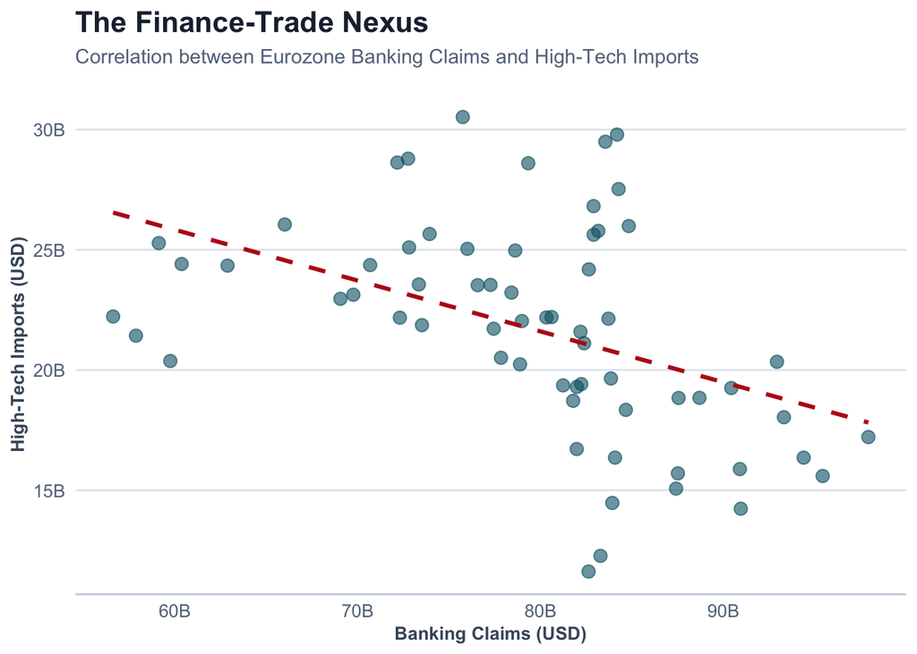

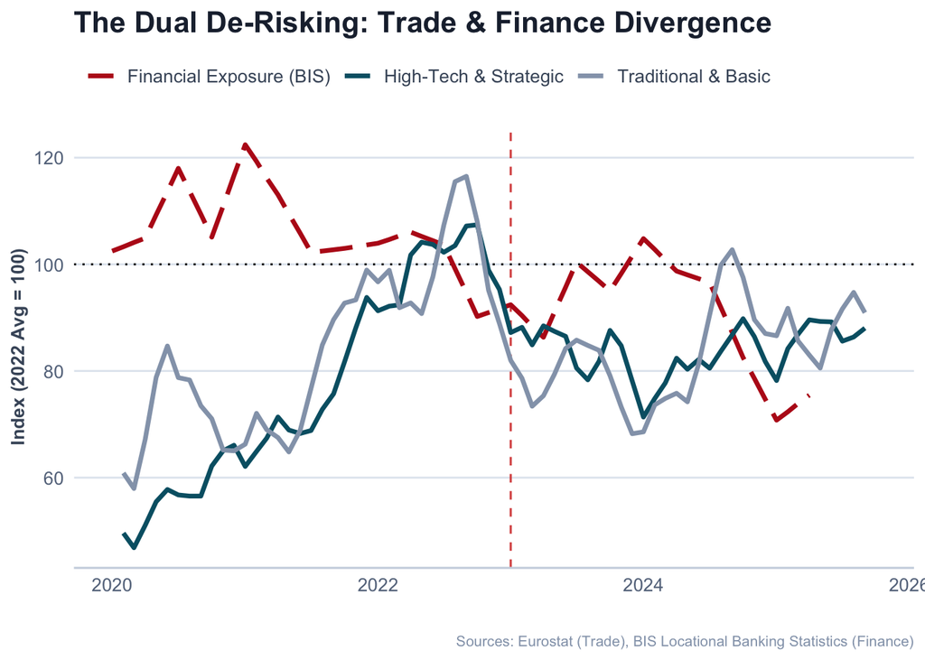

### Forecast and Policy Implications

Looking ahead, we project the “New Normal” trajectory for strategic trade. Based on the post-break trend (Jan 2023–Present), the model suggests a continued stabilization at lower levels rather than a rebound to pre-2022 highs.

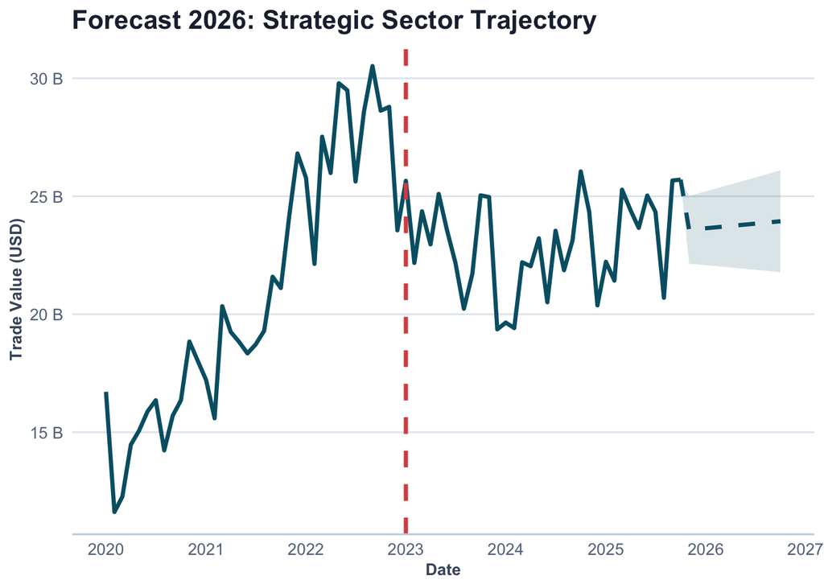

Figure 5: Projecting the ‘De-risking’ Trend into 2026 based on linear extrapolation of the post-break trajectory.

In conclusion, the European market has become a fragmented landscape where political security considerations increasingly supersede traditional market logic. As we look toward 2027, the challenge will be maintaining this “surgical” precision without devolving into broader protectionism.

# References

1. Bank for International Settlements. (2026). Locational banking statistics.
2. Chow, G. C. (1960). Tests of equality between sets of coefficients in two linear regressions. *Econometrica*.
3. European Commission. (n.d.). China Trade Relationships.
4. Eurostat. (2026). Euro area trade by SITC product group.
5. McNamara, K. R. (2024). Transforming Europe? The EU’s industrial policy and geopolitical turn. *Journal of European Public Policy*.
6. Pereira, I. T. (2025). What are the most imported and exported products between China and the EU? *Euronews*.
7. Vandermeeren, F. (2024). Understanding EU-China economic exposure. *European Commission*.